# Theory Assignment - Residuals, Sums of Squares, and R-Squared

This document will perform a linear regression using a weather data set on the maximum air pressure and max wind speed. We will diagnose five important aspects of this regression: **residuals, SSE, SSR, SSTO, and R-Squared**. At the end of this study guide you will have a better understanding of the importance of these in a linear regression.

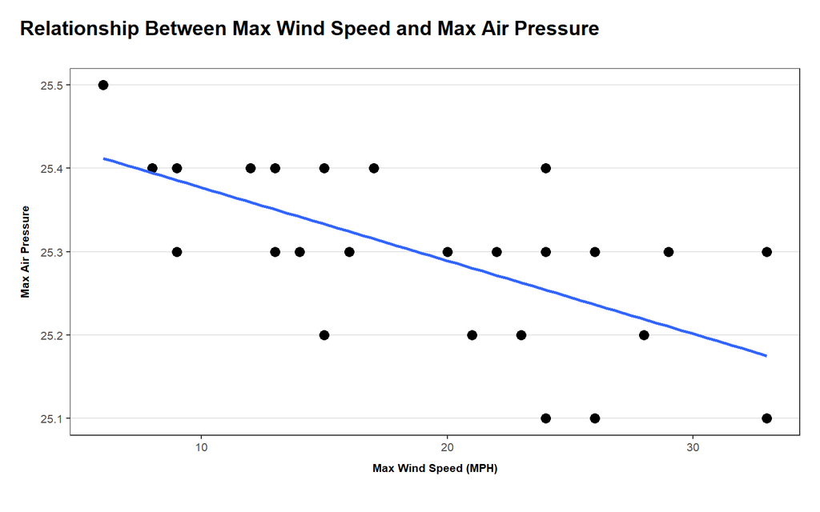

### **Residuals**

Definition:

- the difference between an observed y-value point and an estimated y-value point
- this gives insight about how much an individual of a given x-value differs from average in their y-value

Use:

1. Residuals are key to obtaining the “least squares estimates” of the regression parameters β0 and β1.
2. Residuals are an important part in measuring the R^2 value of a regression, which is the proportion of variation in Y explained by the regression model.
3. Third, residuals give insight about how much an individual of a given x-value differs from average in their y-value.
4. Fourth, residuals can be used to estimate the variance parameter of a regression (σ^2) in the equation
5. Fifth, residuals can be used to determine if a linear regression model is appropriate for a given data set

[figure not shown]

### **Sum of Squared Error (Residuals) (SSE)**

Definition:

Use:

- Helps measure the variation of observed data (similar to the use of a histogram)
- If SSE and SSE are the same, the correlation in this regression is very tight, which means is a good fit

Equation: $SSE = \sum_{i=1}^n (Y_i - \hat{Y}_i)^2$

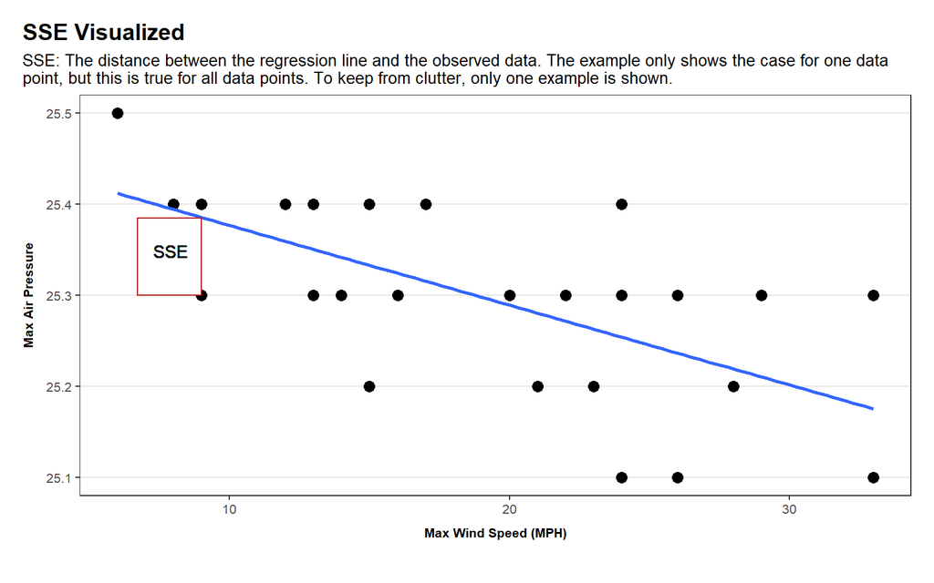

### **Sum of Squared Regression Error (SSR)**

Definition:

- Distance from the regression line to y-bar(the dashed horizontal line showing the mean of all y-values)

Equation: $SSR = \sum_{i=1}^n (\hat{Y}_i - \bar{Y})^2$

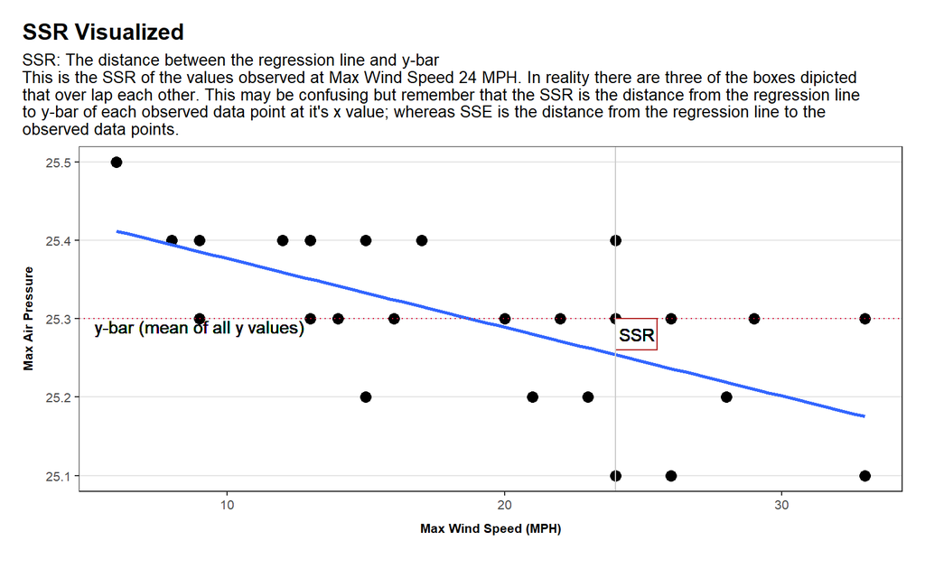

### **Total Sum of Squares (SSTO)**

Definition:

- This stands for *Total Sum of Squares*. Measure of total variation in Y
- SSE + SSR = SSTO

Equation: $SSR + SSE = SSTO = \sum_{i=1}^n (Y_i - \bar{Y})^2$

### **R-Squared**

Definition:

- Proportion of variation in Y explained by the regression

We get R^2 by SSR / SSTO.

The plots below visualize the differences in r-squared values

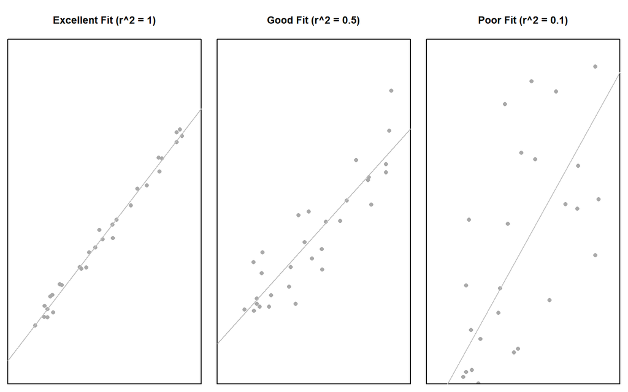